# Data Analysis and Visualization in R

Jenn Schilling

June 5, 2022

This file contains contains code for pre-conference AIR Forum Workshop: Data Analysis Visualization in R, presented for the Association for Institutional Research by Jenn Schilling on June 5, 2022.

**Materials developed by Jenn Schilling.**

# Setup

```r
# Set default chunk options
knitr::opts_chunk$set(echo = TRUE, message = FALSE)

# Set the default size of figures
knitr::opts_chunk$set(fig.width = 8, fig.height = 5)

# Load libraries
library(here)
library(explore)
library(tidyverse)
library(scales)
```

# Read the Data

```r
# Data from IPEDS
ipeds_char <- read_csv(here("data", "IPEDS_inst_char.csv"))
ipeds_adm <- read_csv(here("data", "IPEDS_inst_adm.csv"))
ipeds_enrl <- read_csv(here("data", "IPEDS_inst_enrl.csv"))
ipeds_compl <- read_csv(here("data", "IPEDS_inst_compl.csv"))
```

# Data Exploration

```r
# Interactive exploration of the data
explore(ipeds_adm)

# Create a report for exploratory data analysis
report(ipeds_adm,
       output_file = "ipeds_adm_report.html",
       output_dir = here("output"))

# Create a report for exploratory data analysis with a target variable
report(ipeds_adm,
       output_file = "ipeds_adm_report_target.html",
       output_dir = here("output"),
       target = n_enrl)
```

## Data Exploration - Your Turn

Use the `explore()` or `report()` to explore one of the other IPEDS datasets.

What do you notice?

Are there any outliers or unusual patterns in any variable?

Are there any missing values?

Does the shape of the data reveal anything interesting?

Learn more at the package website: https://github.com/rolkra/explore

# Data Analysis

```r
## Summarize Data ##

# General, base summary of every column/variable
summary(ipeds_adm)
```

```
##       year          unitid          instnm           n_applicants
##  Min.   :2017   Min.   :104179   Length:63          Min.   : 24132
##  1st Qu.:2018   1st Qu.:139884   Class :character   1st Qu.: 38153
##  Median :2018   Median :171100   Mode  :character   Median : 43473
##  Mean   :2018   Mean   :175699                      Mean   : 48659
##  3rd Qu.:2019   3rd Qu.:221750                      3rd Qu.: 48640
##  Max.   :2020   Max.   :240444                      Max.   :113754
##
##     n_admits         n_enrl        test_req             n_sat
##  Min.   : 9525   Min.   : 4156   Length:63          Min.   :  438
##  1st Qu.:16743   1st Qu.: 5972   Class :character   1st Qu.: 2081
##  Median :23592   Median : 6992   Mode  :character   Median : 4785
##  Mean   :23492   Mean   : 7089                      Mean   : 4194
##  3rd Qu.:26877   3rd Qu.: 7904                      3rd Qu.: 5692
##  Max.   :72880   Max.   :15989                      Max.   :12350
##                                                     NA's   :2
##     pct_sat        sat_score        n_act         pct_act        act_score
##  Min.   : 9.00   Min.   :1190   Min.   : 946   Min.   :13.00   Min.   :35.00
##  1st Qu.:36.00   1st Qu.:1260   1st Qu.:2712   1st Qu.:39.00   1st Qu.:40.00
##  Median :63.00   Median :1340   Median :3879   Median :53.00   Median :42.50
##  Mean   :57.66   Mean   :1317   Mean   :3864   Mean   :56.25   Mean   :41.79
##  3rd Qu.:79.00   3rd Qu.:1370   3rd Qu.:4969   3rd Qu.:78.00   3rd Qu.:43.50
##  Max.   :90.00   Max.   :1420   Max.   :6973   Max.   :95.00   Max.   :47.00
##  NA's   :2       NA's   :2      NA's   :2      NA's   :2       NA's   :2
```

```r
# Compute summary statistics for each institution
ipeds_adm_summary <- ipeds_adm %>%
  group_by(instnm) %>%
  summarize(median_applicants = median(n_applicants, na.rm = TRUE),
            mean_applicants = mean(n_applicants, na.rm = TRUE),
            std_applicants = sd(n_applicants, na.rm = TRUE),
            max_applicants = max(n_applicants, na.rm = TRUE),
            min_applicants = min(n_applicants, na.rm = TRUE),
            num_years = n()) %>%
  ungroup()

View(ipeds_adm_summary)

## Manipulate Data ##

# Add a new column
ipeds_adm_new_col <- ipeds_adm %>%
  mutate(yield = n_admits / n_applicants)

View(ipeds_adm_new_col)

# Filter data to get rows of interest
ipeds_adm_subset_rows <- ipeds_adm %>%
  filter(year >= 2019)

View(ipeds_adm_subset_rows)

# Select only columns of interest
ipeds_adm_subset_col <- ipeds_adm %>%
  select(year, unitid, instnm, n_applicants, n_sat, sat_score, n_act, act_score)

View(ipeds_adm_subset_col)

# Add more columns/variables by joining
View(ipeds_adm)
View(ipeds_char)

ipeds_adm_char <- left_join(ipeds_adm, ipeds_char, by = c("unitid", "instnm"))

View(ipeds_adm_char)


## Correlation ##
ipeds_adm_corr <- cor(ipeds_adm$n_admits, ipeds_adm$n_enrl)

ipeds_adm_corr
```

```
## [1] 0.6742077
```

```r
## Linear Regression ##
ipeds_adm_model <- lm(n_enrl ~ n_admits, data = ipeds_adm)

summary(ipeds_adm_model)
```

```
##
## Call:
## lm(formula = n_enrl ~ n_admits, data = ipeds_adm)
##
## Residuals:
##     Min      1Q  Median      3Q     Max
## -2756.6  -915.3    46.9   512.6  4196.4
##
## Coefficients:
##              Estimate Std. Error t value Pr(>|t|)
## (Intercept) 3.586e+03  5.279e+02   6.793 5.26e-09 ***
## n_admits    1.491e-01  2.091e-02   7.130 1.39e-09 ***
## ---
## Signif. codes:  0 '***' 0.001 '**' 0.01 '*' 0.05 '.' 0.1 ' ' 1
##
## Residual standard error: 1535 on 61 degrees of freedom
## Multiple R-squared:  0.4546, Adjusted R-squared:  0.4456
## F-statistic: 50.84 on 1 and 61 DF,  p-value: 1.386e-09
```

## Data Analysis - Your Turn

Use the `summarize()` function to create summary statistics for a different column or different IPEDS dataset.

Try to add a new column with the `mutate()` function or subset the data using `filter()` or `select()` in one of the IPEDS datasets.

Put two IPEDS datasets together using a `left_join()`, `right_join()`, or `inner_join()`.

Explore a linear regression using `corr()` and `lm()`.

Learn more at the package website: https://dplyr.tidyverse.org/

If your data is not already in tidy format, the {tidyr} package provides useful functions for processing data. Learn more at the package website: https://tidyr.tidyverse.org/

# Data Visualization

## Scatterplot

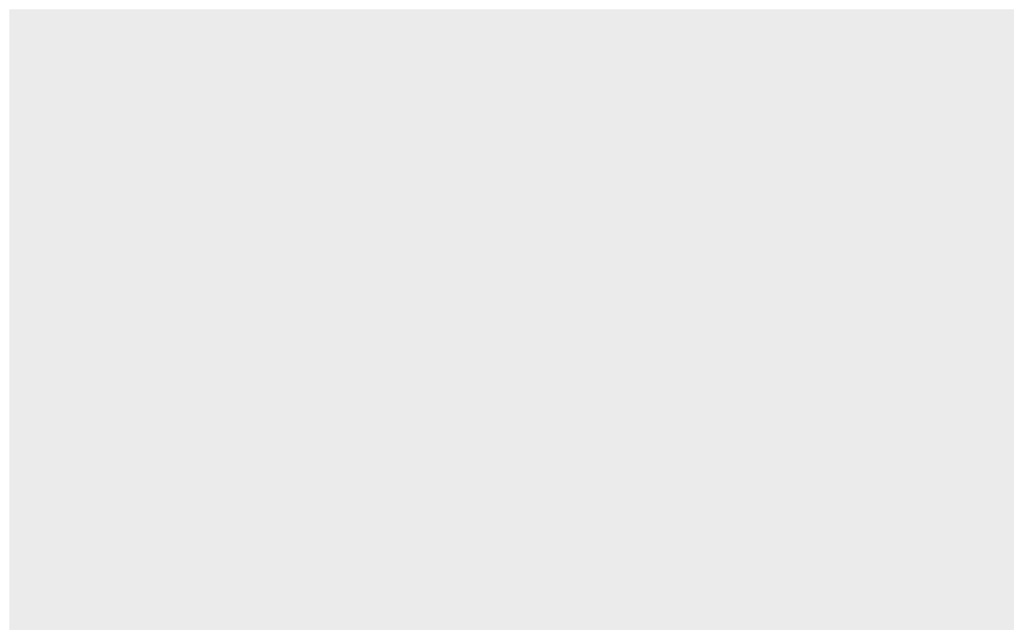

```r
# Is there a relationship between SAT score and ACT score in Fall 2019?

# Get the data ready for the plot
ipeds_adm_plot <- ipeds_adm %>%
  filter(year == 2019)

# Step 1: Specify the data
ggplot(data = ipeds_adm_plot)
```

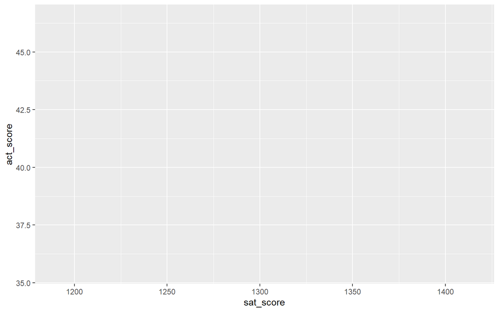

```r
# Step 2: Specify the aesthetic mapping
ggplot(data = ipeds_adm_plot,
       mapping = aes(x = sat_score,
                     y = act_score))
```

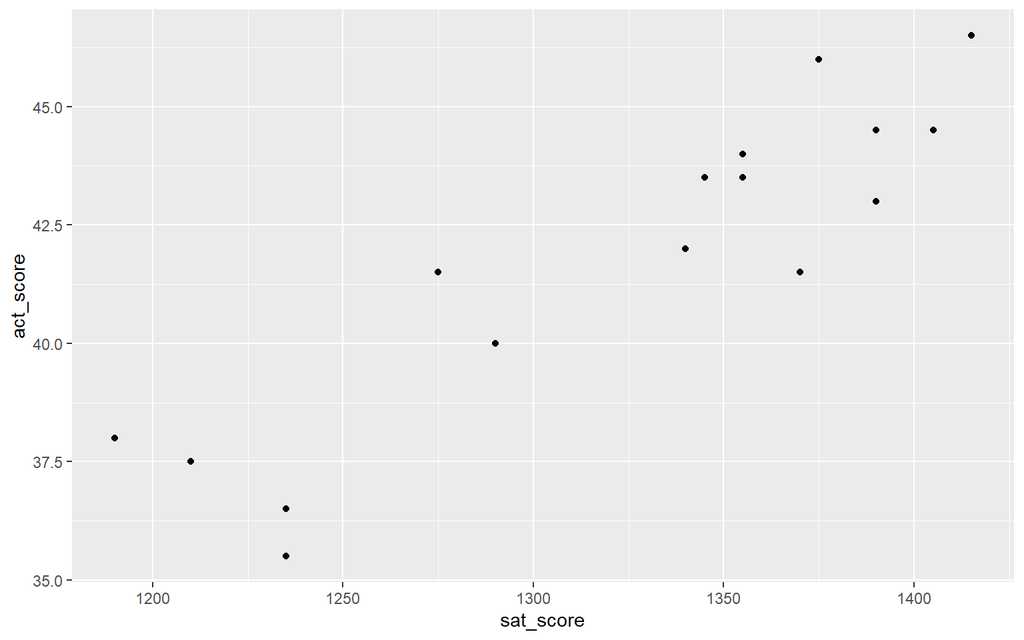

```r
# Step 3: Specify the geometric object
ggplot(data = ipeds_adm_plot,
       mapping = aes(x = sat_score,
                     y = act_score)) +
  geom_point()
```

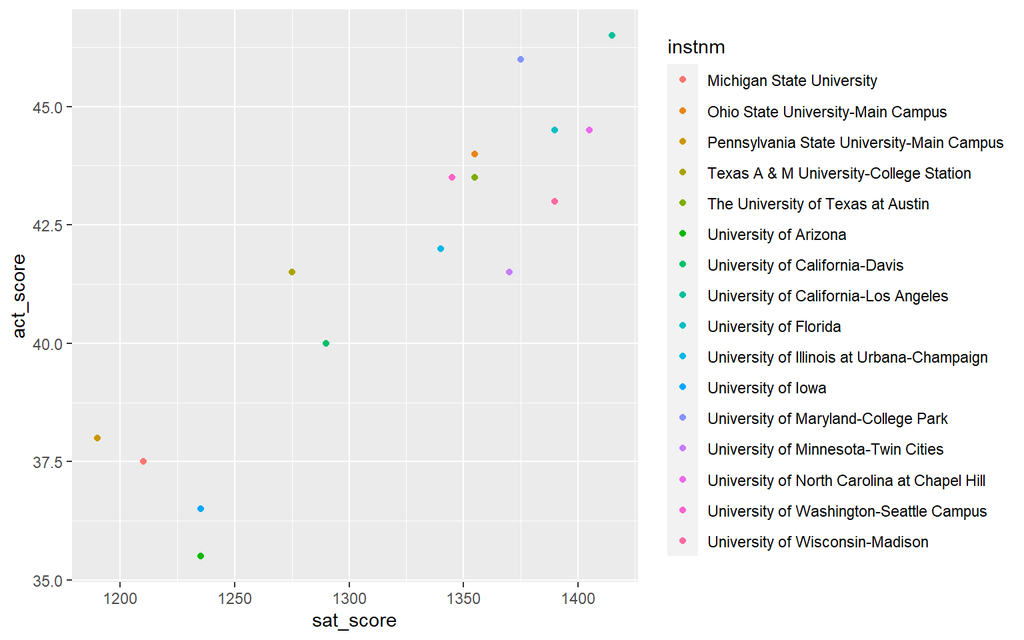

```r
# Step 4: Add to aesthetic mapping

# Categorical color
ggplot(data = ipeds_adm_plot,
       mapping = aes(x = sat_score,
                     y = act_score,
                     color = instnm)) +
  geom_point()
```

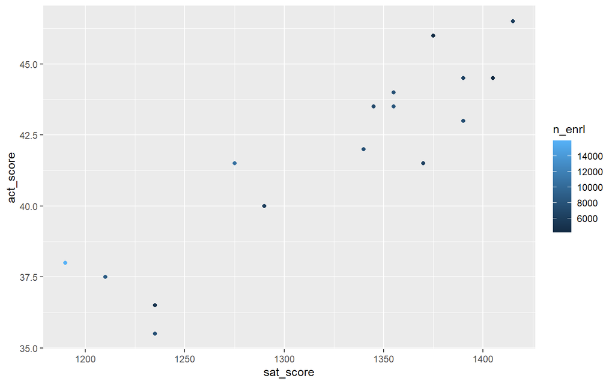

```r
# Sequential color
ggplot(data = ipeds_adm_plot,
       mapping = aes(x = sat_score,
                     y = act_score,
                     color = n_enrl)) +
  geom_point()
```

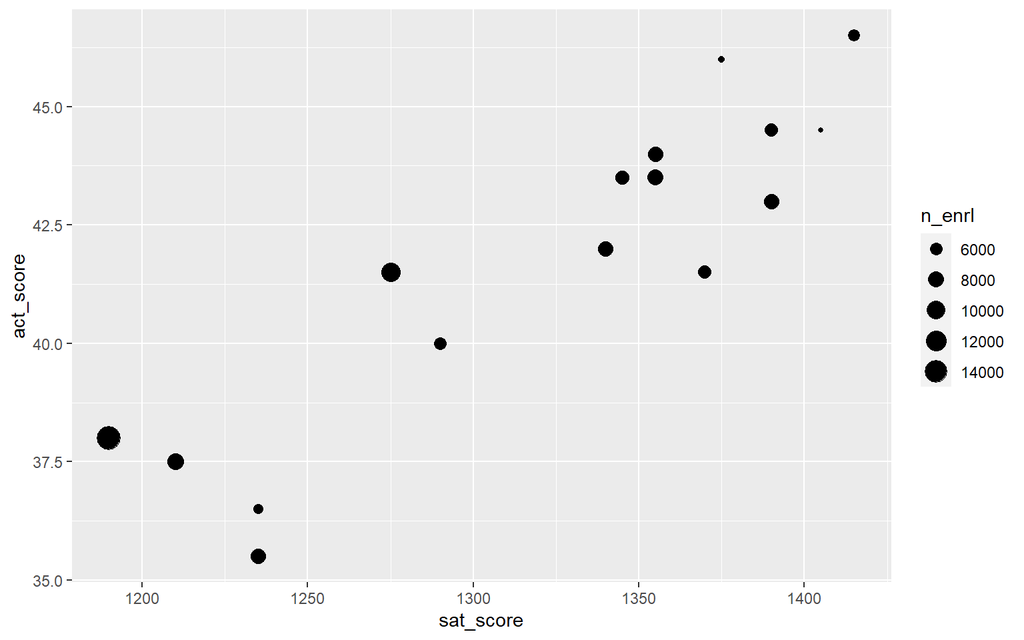

```r
# Size
ggplot(data = ipeds_adm_plot,
       mapping = aes(x = sat_score,
                     y = act_score,
                     size = n_enrl)) +
  geom_point()
```

## Line Graph

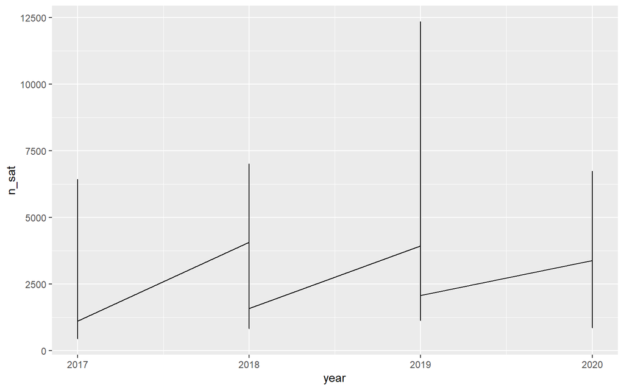

```r
# How does the number of students who submit an SAT score change over time?

# This time, we will use the whole ipeds_adm dataset

# Set up the data, aesthetic mapping, and geometric objects
ggplot(data = ipeds_adm,
       mapping = aes(x = year,
                     y = n_sat)) +
  geom_line()
```

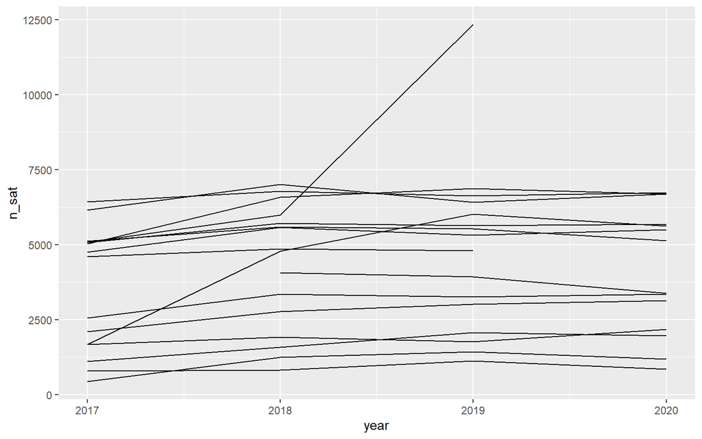

```r
# Something doesn't look right - there is only one line

# Need to add the group argument in the aes() mapping to tell R to create one line per group (institution)
ggplot(data = ipeds_adm,
       mapping = aes(x = year,
                     y = n_sat,
                     group = instnm)) +
  geom_line()
```

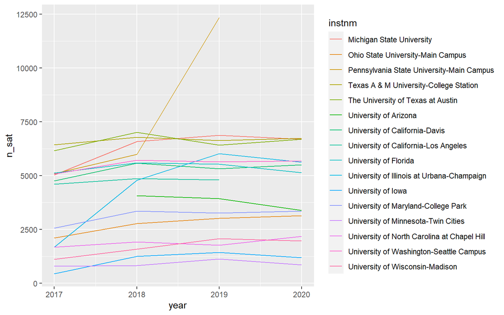

```r
# How can we identify the outlier?

# Option 1: Add Color
ggplot(data = ipeds_adm,
       mapping = aes(x = year,
                     y = n_sat,
                     group = instnm,
                     color = instnm)) +
  geom_line()
```

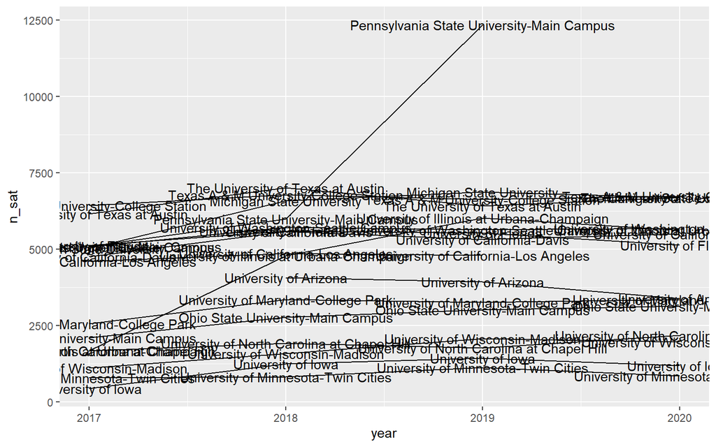

```r
# Option 2: Add Labels
# 2a: Add label for every data point
ggplot(data = ipeds_adm,
       mapping = aes(x = year,
                     y = n_sat,
                     group = instnm,
                     label = instnm)) +
  geom_line() +
  geom_text()
```

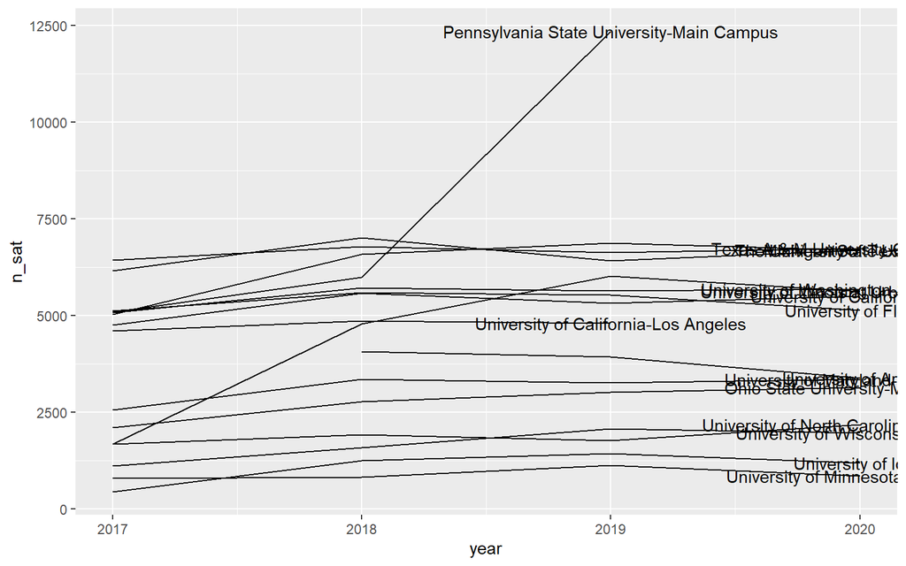

```r
# 2b: Add label for only the last data point

# We can set data and mapping arguments for individual geometric objects

# First, let's make a new data table with only the labels
ipeds_adm_labels <- ipeds_adm %>%
  filter(!is.na(n_sat)) %>% # remove NA values for n_sat
  group_by(instnm) %>% # group the data by institution
  summarise(year = max(year)) %>% # find the maximum year
  ungroup() %>% # remove grouping
  left_join(ipeds_adm, by = c("instnm", "year")) %>% # join to original dataset to get the n_sat value for that year
  select(instnm, year, n_sat) # keep only the columns we need

# Plot
ggplot(data = ipeds_adm,
       mapping = aes(x = year,
                     y = n_sat,
                     group = instnm)) +
  geom_line() +
  geom_text(data = ipeds_adm_labels,
            mapping = aes(x = year,
                          y = n_sat,
                          label = instnm))
```

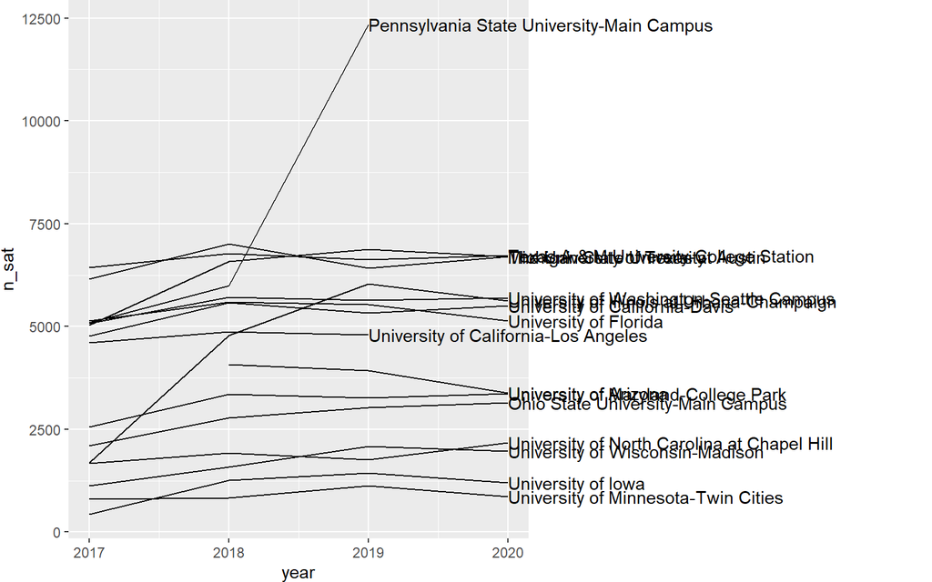

```r
# Format labels and allow them to show outside the plot area
ggplot(data = ipeds_adm,
       mapping = aes(x = year,
                     y = n_sat,
                     group = instnm)) +
  geom_line() +
  geom_text(data = ipeds_adm_labels,
            mapping = aes(x = year,
                          y = n_sat,
                          label = instnm),
            hjust = 0) +
  coord_cartesian(clip = "off") + # show the labels even though they are outside the plot area
  theme(plot.margin = margin(0, 250, 0, 0)) # expand the plot margin so we can see the labels
```

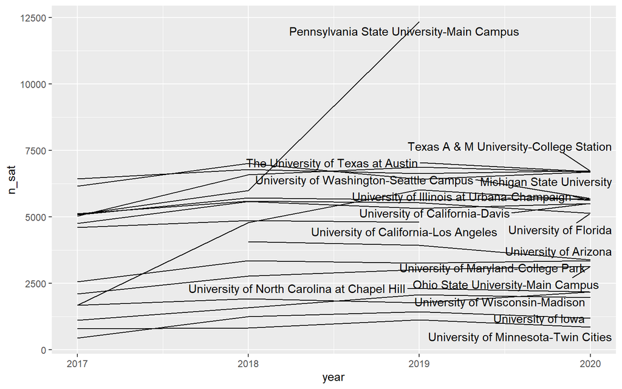

```r
# Format labels so they do not overlap
library(ggrepel)
ggplot(data = ipeds_adm,
       mapping = aes(x = year,
                     y = n_sat,
                     group = instnm)) +
  geom_line() +
  geom_text_repel(data = ipeds_adm_labels,
                  mapping = aes(x = year,
                                y = n_sat,
                                label = instnm))
```

## Bar Graph

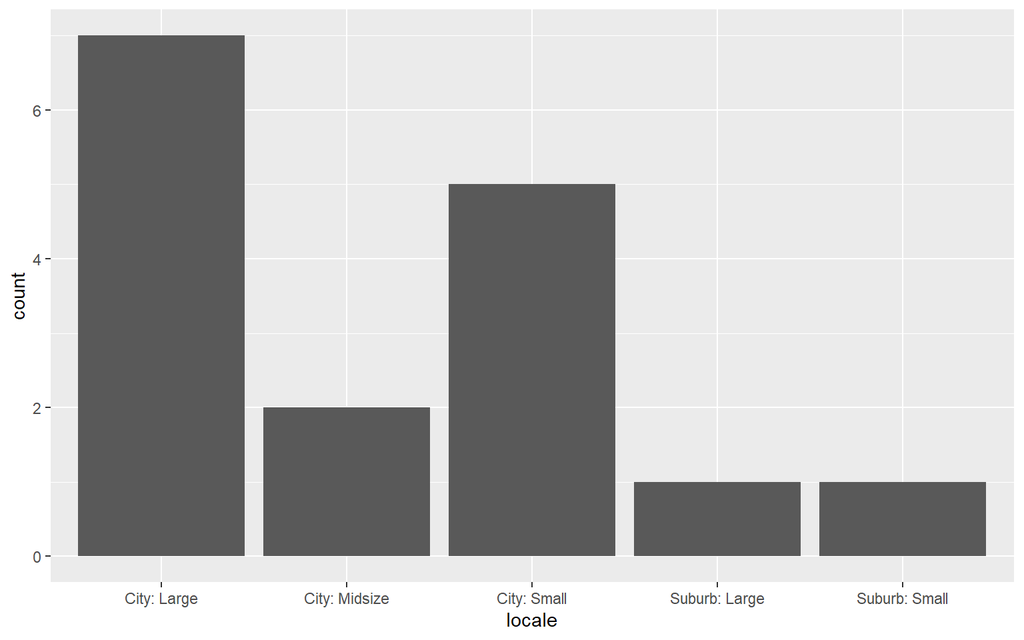

```r
# How many institutions are in each type of locale?

# Set up the data, aesthetic mapping, and geometric objects
ggplot(data = ipeds_char,
       mapping = aes(x = locale)) +
  geom_bar()
```

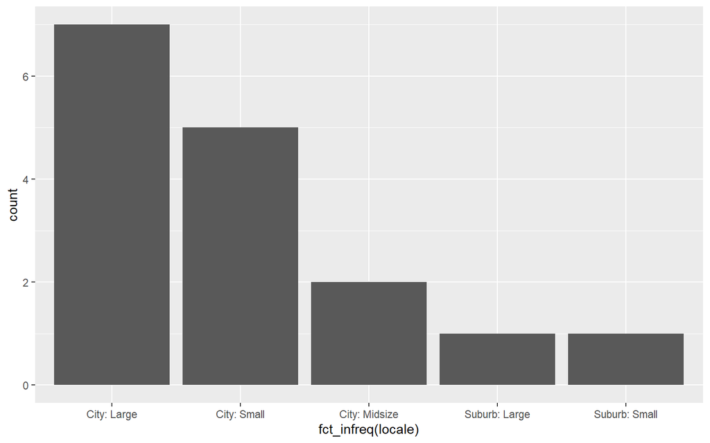

```r
# geom_bar() computes counts for us - we just need to provide the x-axis category

# Can we sort them?
# Yes, by using the fct_infreq() function from the forcats package in tidyverse
# fct_infreq() reorders the levels by their frequencies
ggplot(data = ipeds_char,
       mapping = aes(x = fct_infreq(locale))) +
  geom_bar()
```

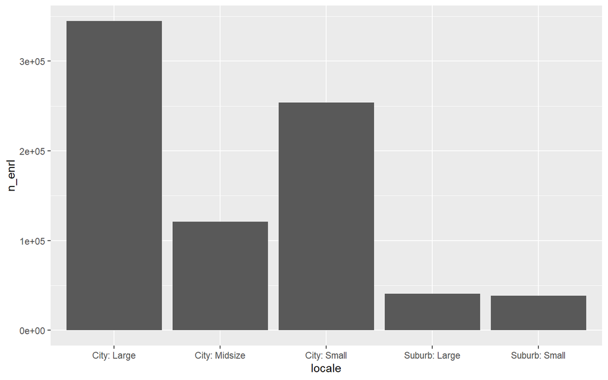

```r
# What if we want to make a bar plot with something other than counts?

# Create a new dataset with enrollment data and institutional characteristics
inst_enrlmnt_data <- left_join(ipeds_char, ipeds_enrl, by = c("unitid", "instnm"))

View(inst_enrlmnt_data)

# What does enrollment look like by locale?

# Plot total enrollment of all students in Fall 2019 by locale
ggplot(data = inst_enrlmnt_data %>%
         filter(lstudy == "All students", gender == "Total", year == 2019),
       mapping = aes(x = locale,
                     y = n_enrl)) +
  geom_col() # geom_col() plots a bar with the data specified in the y argument of aes()
```

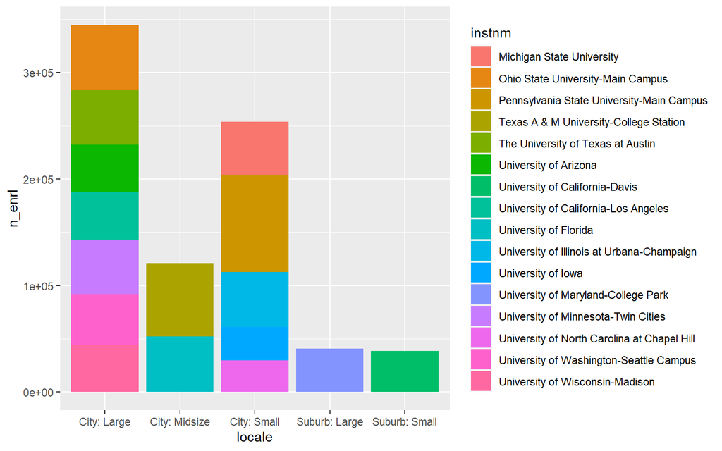

```r
# Let's see what's actually happening in this plot - the enrollments for each institution are stacked on top of one another
ggplot(data = inst_enrlmnt_data %>%
         filter(lstudy == "All students", gender == "Total", year == 2019),
       mapping = aes(x = locale,
                     y = n_enrl,
                     fill = instnm)) + # fill adds color to a bar plot
  geom_col()
```

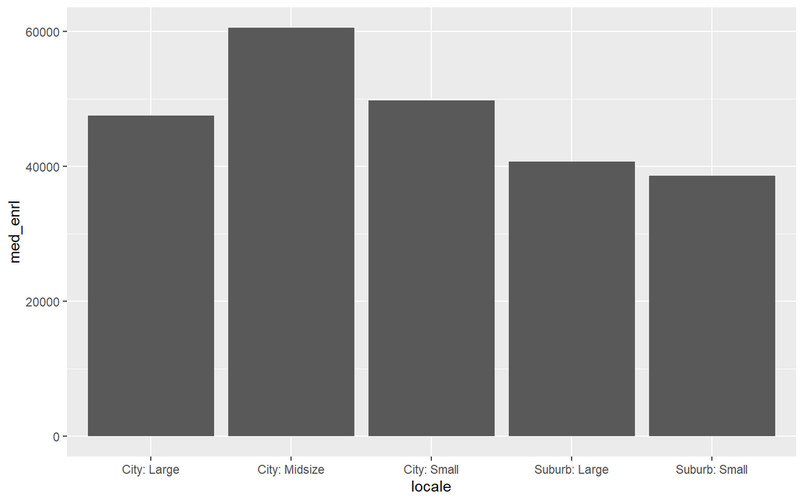

```r
# What if we want the median enrollment in each area?
# We can use filter(), group_by(), and summarize() to compute an aggregation
inst_enrlmnt_data_sub <- inst_enrlmnt_data %>%
  filter(lstudy == "All students", gender == "Total", year == 2019) %>%
  group_by(locale) %>%
  summarize(med_enrl = median(n_enrl)) %>%
  ungroup()

View(inst_enrlmnt_data_sub)

ggplot(data = inst_enrlmnt_data_sub,
       mapping = aes(x = locale,
                     y = med_enrl)) +
  geom_col()
```

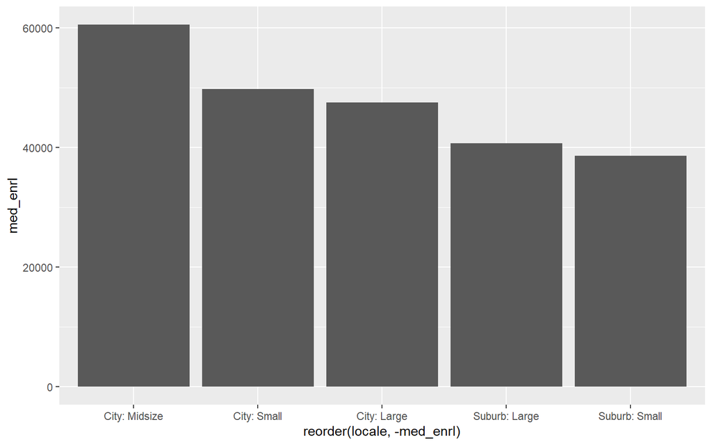

```r
# Now plot the aggregated data and arrange the bars in order of median enrollemtn
# This time, use the reorder() function to arrange the locale column by the med_enrl column because we have a numeric value we want to use for the ordering
ggplot(data = inst_enrlmnt_data_sub,
       mapping = aes(x = reorder(locale, -med_enrl),
                     y = med_enrl)) +
  geom_col()
```

## Pie Chart

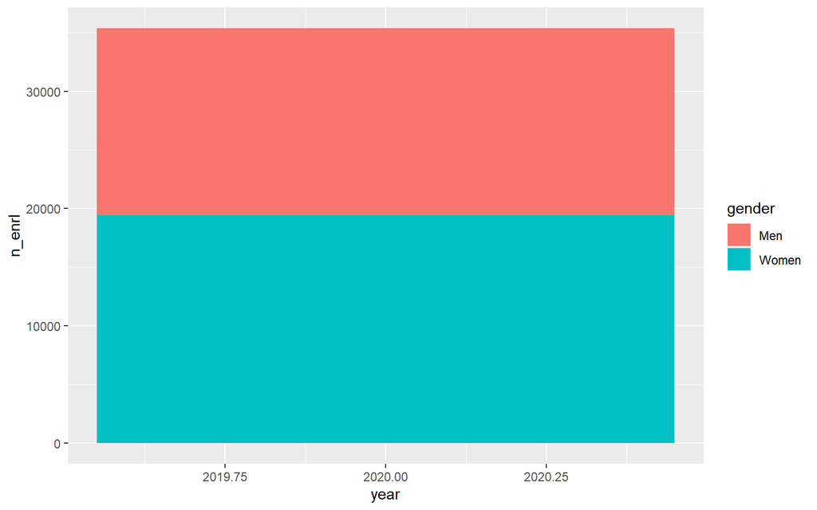

```r
# What proportion of undergraduate enrollment at the University of Arizona in Fall 2020 was men vs. women?

# Get the subset of the data we're interested in
ua_enrl <- ipeds_enrl %>%
  filter(unitid == 104179 & year == 2020 & gender != "Total" & lstudy == "Undergraduate")

View(ua_enrl)

# Plot the data, aesthetics mapping, and geometric object
ggplot(data = ua_enrl,
       mapping = aes(x = year,
                     y = n_enrl,
                     fill = gender)) +
  geom_col()
```

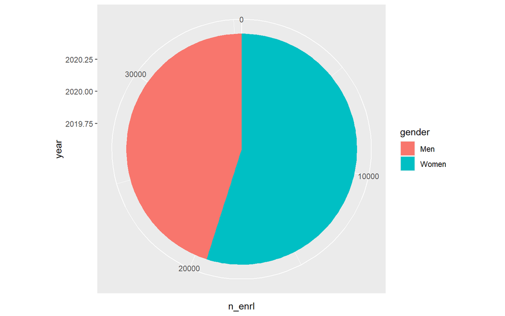

```r
# Change the coordinate system to make a pie chart
ggplot(data = ua_enrl,
       mapping = aes(x = year,
                     y = n_enrl,
                     fill = gender)) +
  geom_col() +
  coord_polar(theta = "y")
```

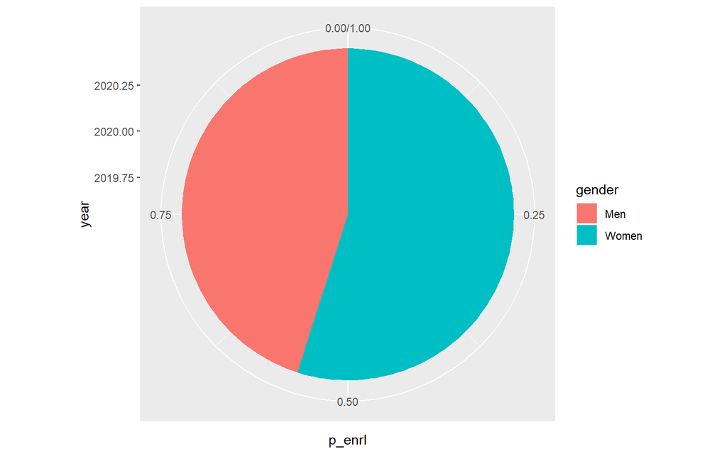

```r
# What if we want to use percentages?

# Make a new data table with the percentages
ua_enrl_perc <- ua_enrl %>%
  mutate(p_enrl = n_enrl / sum(n_enrl))

View(ua_enrl_perc)

# Plot the percentages
ggplot(data = ua_enrl_perc,
       mapping = aes(x = year,
                     y = p_enrl,
                     fill = gender)) +
  geom_col() +
  coord_polar(theta = "y",
              start = 0)
```

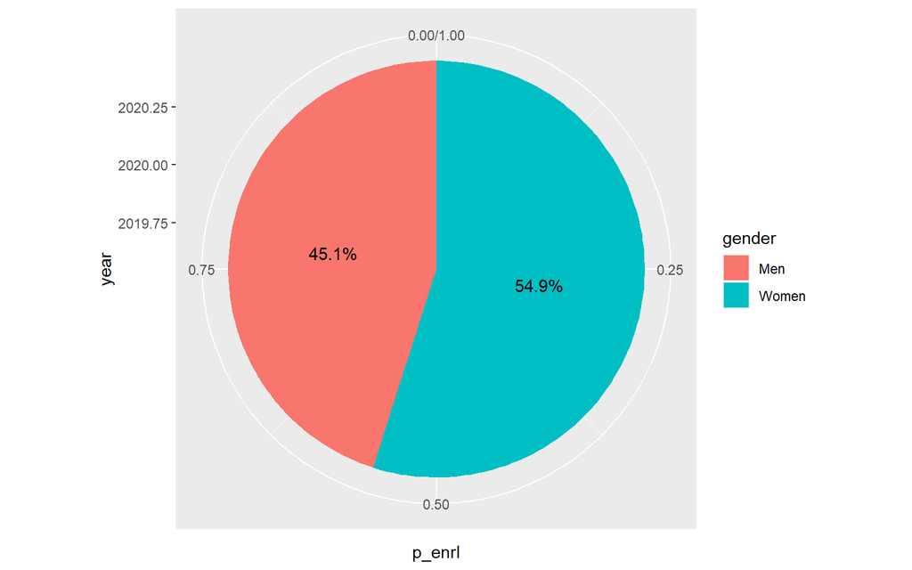

```r
# Add labels
ggplot(data = ua_enrl_perc,
       mapping = aes(x = year,
                     y = p_enrl,
                     fill = gender,
                     label = percent(p_enrl))) +
  geom_col() +
  geom_text(position = position_fill(vjust = 0.5)) +
  coord_polar(theta = "y",
              start = 0)
```

## Faceting

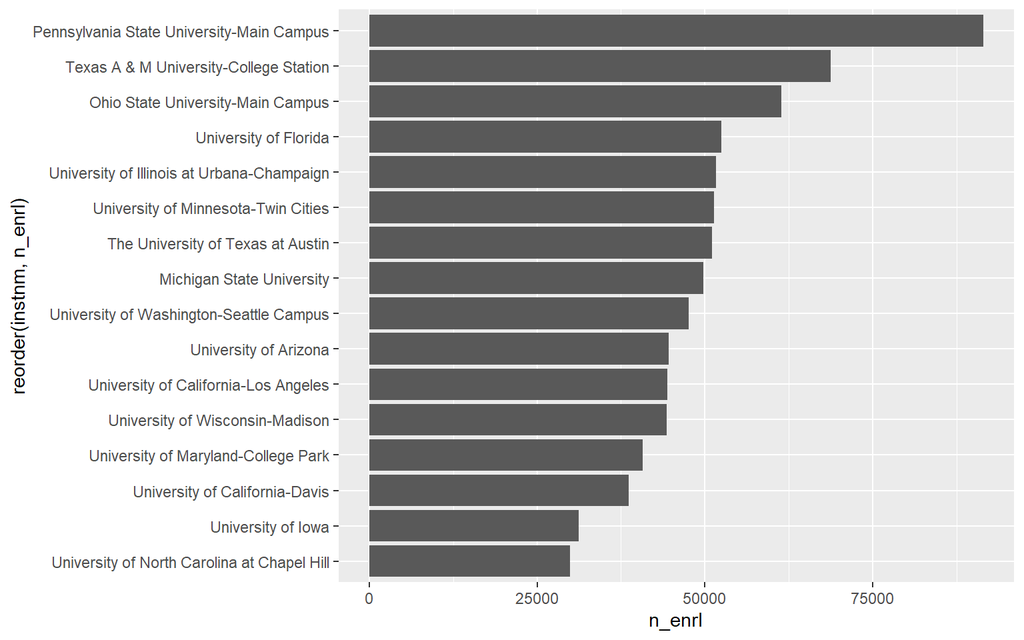

```r
# What does enrollment look like by institution and locale?

# Plot the data, aesthetic mapping, and geometric object
ggplot(data = inst_enrlmnt_data %>%
         filter(lstudy == "All students",
                gender == "Total",
                year == 2019),
       mapping = aes(x = n_enrl,
                     y = reorder(instnm, n_enrl))) +
  geom_col()
```

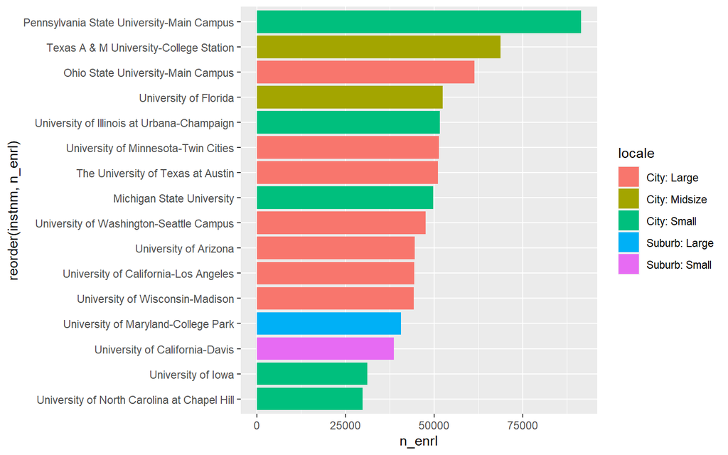

```r
# We could add color to see the locale
ggplot(data = inst_enrlmnt_data %>%
         filter(lstudy == "All students",
                gender == "Total",
                year == 2019),
       mapping = aes(x = n_enrl,
                     y = reorder(instnm, n_enrl),
                     fill = locale)) +
  geom_col()
```

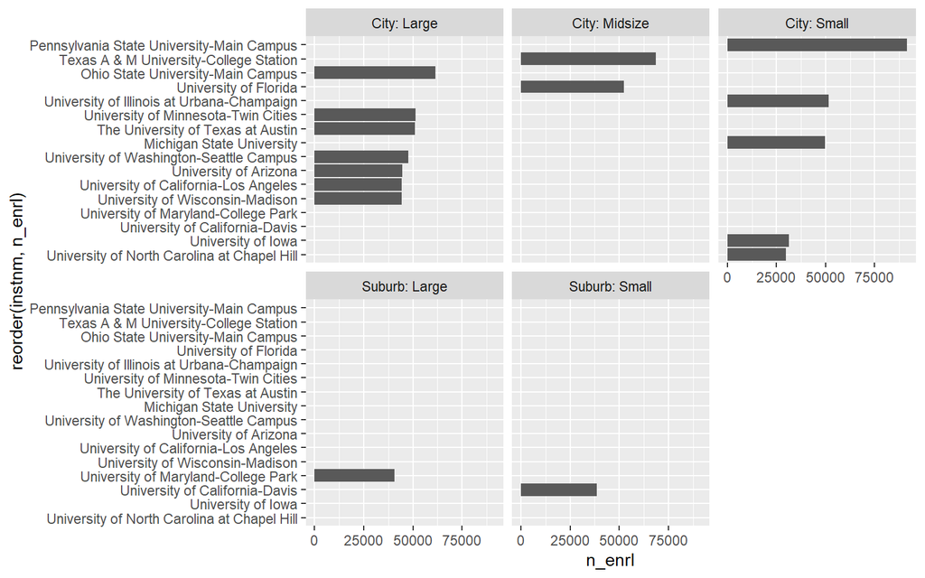

```r
# Or we could make small charts for each locale
ggplot(data = inst_enrlmnt_data %>%
         filter(lstudy == "All students",
                gender == "Total",
                year == 2019),
       mapping = aes(x = n_enrl,
                     y = reorder(instnm, n_enrl))) +
  geom_col() +
  facet_wrap(~ locale) # Make a small plot for each locale
```

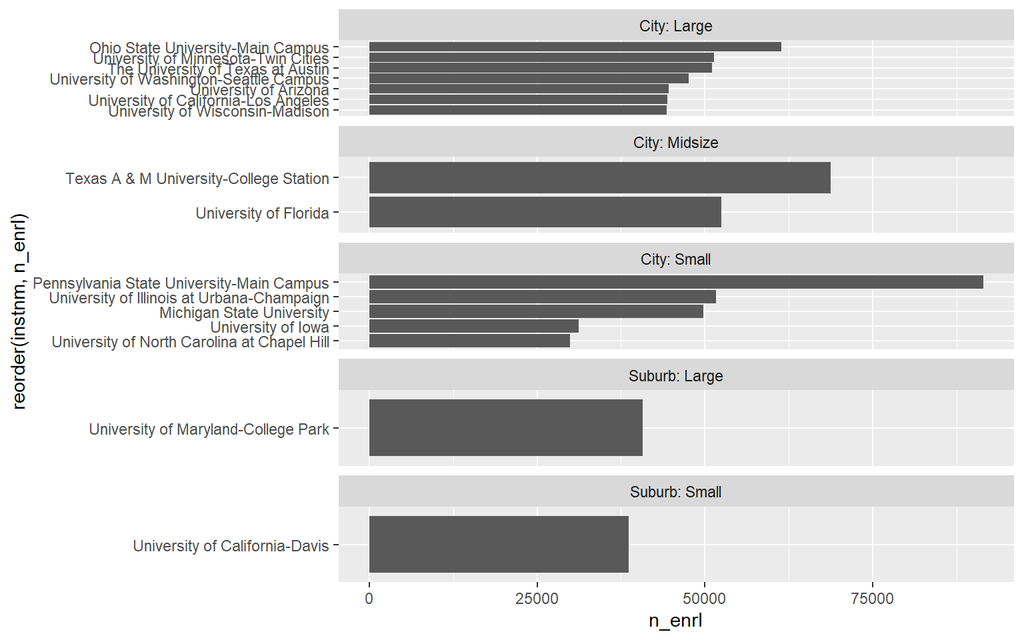

```r
# Make some formatting changes for the facets
ggplot(data = inst_enrlmnt_data %>%
         filter(lstudy == "All students",
                gender == "Total",
                year == 2019),
       mapping = aes(x = n_enrl,
                     y = reorder(instnm, n_enrl))) +
  geom_col() +
  facet_wrap(~ locale,
             ncol = 1, # Put all the plots in one column
             scales = "free_y") # Let the y-axis be "free" so only the relevant institutions to that locale show
```

## Facets with Bars and Lines

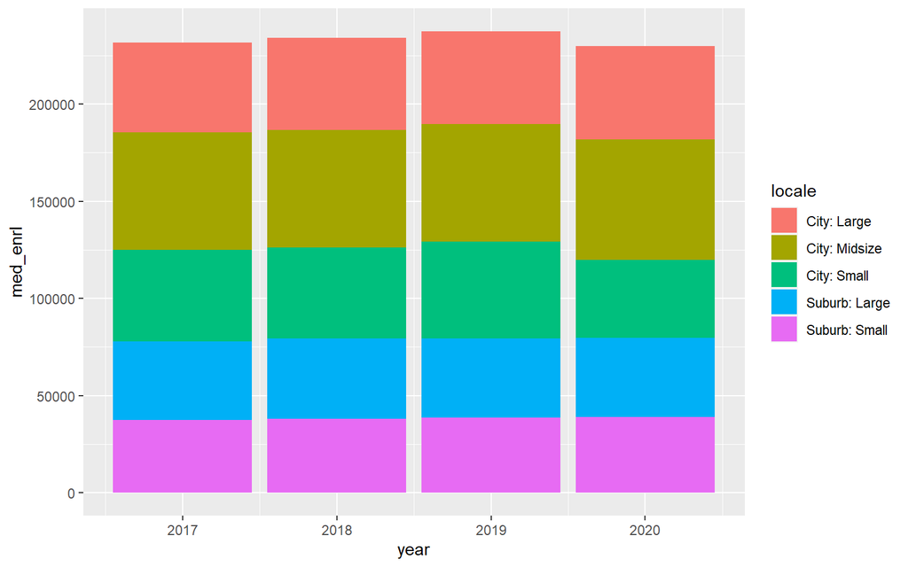

```r
# What does median enrollment look like over time in each locale?

# Make a sub dataset for the plot
inst_enrlmnt_data_sub <- inst_enrlmnt_data %>%
  filter(lstudy == "All students", gender == "Total") %>%
  group_by(year, locale) %>%
  summarize(med_enrl = median(n_enrl),
            .groups = "drop")

View(inst_enrlmnt_data_sub)

# Plot - this creates a stacked bar graph
ggplot(data = inst_enrlmnt_data_sub,
       mapping = aes(x = year,
                     y = med_enrl,
                     fill = locale)) +
  geom_col()
```

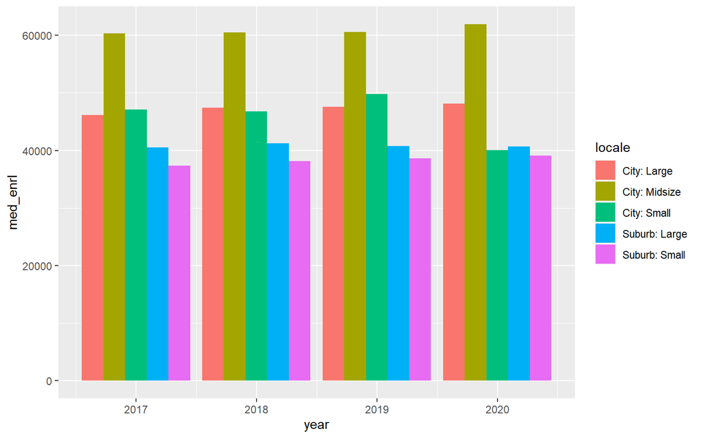

```r
# Plot - this creates a side-by-side bar graph
ggplot(data = inst_enrlmnt_data_sub,
       mapping = aes(x = year,
                     y = med_enrl,
                     fill = locale)) +
  geom_col(position = "dodge")
```

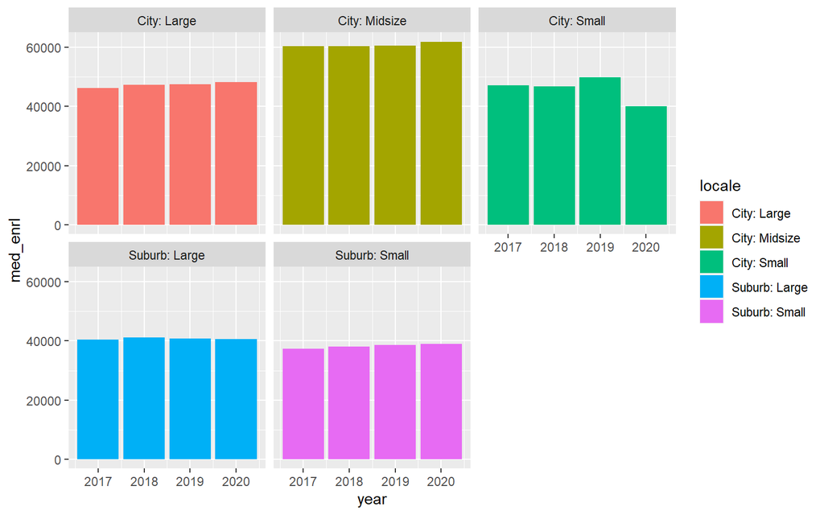

```r
# Make a small plot for each locale
ggplot(data = inst_enrlmnt_data_sub,
       mapping = aes(x = year,
                     y = med_enrl,
                     fill = locale)) +
  geom_col(position = "dodge") +
  facet_wrap(~ locale)
```